# Google Data Analytics Captsone Project

Juan Vizuete

2024-08-08

# Google Data Analytics Capstone Project: Cyclistic bike-share program

## Introduction and Background

[figure not shown]

Cyclistic-logo

### Scenario

You are a junior data analyst working on the marketing analyst team at Cyclistic, a bike-share company in Chicago. The director of marketing believes the company’s future success depends on maximizing the number of annual memberships. Therefore, your team wants to understand how casual riders and annual members use Cyclistic bikes differently. From these insights, your team will design a new marketing strategy to convert casual riders into annual members. But first, Cyclistic executives must approve your recommendations, so they must be backed up with compelling data insights and professional data visualizations.

### Characters and teams

- Cyclistic: A bike-share program that features more than 5,800 bicycles and 600 docking stations. Cyclistic sets itself apart by also offering reclining bikes, hand tricycles, and cargo bikes, making bike-share more inclusive to people with disabilities and riders who can’t use a standard two-wheeled bike. The majority of riders opt for traditional bikes; about 8% of riders use the assistive options. Cyclistic users are more likely to ride for leisure, but about 30% use the bikes to commute to work each day.
- Lily Moreno: The director of marketing and your manager. Moreno is responsible for the development of campaigns and initiatives to promote the bike-share program. These may include email, social media, and other channels.
- Cyclistic marketing analytics team: A team of data analysts who are responsible for collecting, analyzing, and reporting data that helps guide Cyclistic marketing strategy. You joined this team six months ago and have been busy learning about Cyclistic’s mission and business goals—as well as how you, as a junior data analyst, can help Cyclistic achieve them.
- Cyclistic executive team: The notoriously detail-oriented executive team will decide whether to approve the recommended marketing program.

### About the company

In 2016, Cyclistic launched a successful bike-share offering. Since then, the program has grown to a fleet of 5,824 bicycles that are geotracked and locked into a network of 692 stations across Chicago. The bikes can be unlocked from one station and returned to any other station in the system anytime.

Until now, Cyclistic’s marketing strategy relied on building general awareness and appealing to broad consumer segments. One approach that helped make these things possible was the flexibility of its pricing plans: single-ride passes, full-day passes, and annual memberships. Customers who purchase single-ride or full-day passes are referred to as casual riders. Customers who purchase annual memberships are Cyclistic members.

Cyclistic’s finance analysts have concluded that annual members are much more profitable than casual riders. Although the pricing flexibility helps Cyclistic attract more customers, Moreno believes that maximizing the number of annual members will be key to future growth.

Rather than creating a marketing campaign that targets all-new customers, Moreno believes there is a solid opportunity to convert casual riders into members. She notes that casual riders are already aware of the Cyclistic program and have chosen Cyclistic for their mobility needs.

Moreno has set a clear goal: Design marketing strategies aimed at converting casual riders into annual members. In order to do that, however, the team needs to better understand how annual members and casual riders differ, why casual riders would buy a membership, and how digital media could affect their marketing tactics. Moreno and her team are interested in analyzing the Cyclistic historical bike trip data to identify trends.

### ASK

#### How do annual members and casual riders use Cyclistic bikes differently

The cyclistic bike-sharing program objective for this task is to find the differences on how annual members and casual riders use the program to develop a new strategy focused on passing casual riders to the annual member program based on their needs, and this will help the business to increase their incomes/sales.

The stakeholders are: * Lily Moreno – Manager/Director of marketing * Cyclistic marketing analytics team * Cyclistic executive team * Cyclists/riders/clients

### PREPARE

According to the official website of divvybikes commitment ([Link Here](https://divvybikes.com/data-license-agreement)), the City permits bikeshare to make certain divvy system data owned by them available to the public. The statements and prohibitions of the use of the data for divvy bikes .csv file are mentioned too.

It is secure because no one else is manipulating the data from the amazon bucket, and the accessibility for any type of person to feel free to downloaded, analyze it, copy, modify and distribute the product. It is reliable because it comes directly from the divvy bike owned data, original because it’s obtained from the original data, comprehensive because they mention the fields that the data contains, current because it is extracted every month and cited because divvy bikes has a data license agreement where they explain everything.

### PROCESS

The tools selected for this project are RStudio (R) and also Excel for some minor checks.

## Importing libraries

Importing the `tidyverse`, `readr`, `janitor`, `DescTools`, `lubridate` libraries

```r
library(tidyverse)
library(readr)
library(janitor)
library(DescTools)
library(lubridate)
library(ggplot2)
```

## Loading the dataset

Loading the divvy bikes dataset

```r
divvy_bikes <- list.files(path = "D:/JUANFRANCISCO/COURSERA/Google Data Analytics/Curso 8 - Capstone/data",
                       pattern = "*.csv", full.names = TRUE) %>%
  lapply(read_csv) %>%
  bind_rows
```

The line code referring to “*bind_rows*” makes sure that all the files contain the same columns and data types to not get any error at the moment of merging all the files.

The data includes 12 files from August 2023 until 08-08-2024 (last uploaded file)

These files were obtained from this [link](https://divvy-tripdata.s3.amazonaws.com/index.html) that was provided by the Google Data Analytics course resources.

[figure not shown]

Dataset files

## Inspecting the dataset

Getting information about the dataset.

```r
glimpse(divvy_bikes)
```

```
## Rows: 5,715,693
## Columns: 13
## $ ride_id            <chr> "903C30C2D810A53B", "F2FB18A98E110A2B", "D0DEC7C94E…
## $ rideable_type      <chr> "electric_bike", "electric_bike", "electric_bike", …
## $ started_at         <dttm> 2023-08-19 15:41:53, 2023-08-18 15:30:18, 2023-08-…
## $ ended_at           <dttm> 2023-08-19 15:53:36, 2023-08-18 15:45:25, 2023-08-…
## $ start_station_name <chr> "LaSalle St & Illinois St", "Clark St & Randolph St…
## $ start_station_id   <chr> "13430", "TA1305000030", "TA1305000030", "KA1504000…
## $ end_station_name   <chr> "Clark St & Elm St", NA, NA, NA, NA, NA, NA, NA, NA…
## $ end_station_id     <chr> "TA1307000039", NA, NA, NA, NA, NA, NA, NA, NA, NA,…
## $ start_lat          <dbl> 41.89072, 41.88451, 41.88498, 41.90310, 41.88555, 4…
## $ start_lng          <dbl> -87.63148, -87.63155, -87.63079, -87.63467, -87.632…
## $ end_lat            <dbl> 41.90297, 41.93000, 41.91000, 41.90000, 41.89000, 4…
## $ end_lng            <dbl> -87.63128, -87.64000, -87.63000, -87.62000, -87.680…
## $ member_casual      <chr> "member", "member", "member", "member", "member", "…
```

- No. Rows: 5715693
- No. Columns: 13

Also, we will check the period of time that the dataset covers by extracting the min and max date from the dates fields

```r
min(divvy_bikes$started_at)
```

```
## [1] "2023-08-01 00:00:06 UTC"
```

```r
max(divvy_bikes$ended_at)
```

```
## [1] "2024-07-31 23:59:56 UTC"
```

The dataset covers the period of time of: 01 August 2023 - 31 July 2024

### Getting ‘NA’ total values in the dataset

By inspecting the dataset, we could see that some columns have ‘NA’ values.

Here we can see the number of ‘NA’ values that has each column:

```r
na_counts <- divvy_bikes %>%
  summarise_all(~ sum(is.na(.)))

glimpse(na_counts)
```

```
## Rows: 1
## Columns: 13
## $ ride_id            <int> 0
## $ rideable_type      <int> 0
## $ started_at         <int> 0
## $ ended_at           <int> 0
## $ start_station_name <int> 947025
## $ start_station_id   <int> 947025
## $ end_station_name   <int> 989476
## $ end_station_id     <int> 989476
## $ start_lat          <int> 0
## $ start_lng          <int> 0
## $ end_lat            <int> 7756
## $ end_lng            <int> 7756
## $ member_casual      <int> 0
```

Not every column has ‘NA’ values, so it means that there are not empty rows.

## Cleaning the data

To check that the column names of the dataset are correct we will use a function inside the `janitor` library

```r
clean_names(divvy_bikes)
```

```
## # A tibble: 5,715,693 × 13
##    ride_id          rideable_type started_at          ended_at
##    <chr>            <chr>         <dttm>              <dttm>
##  1 903C30C2D810A53B electric_bike 2023-08-19 15:41:53 2023-08-19 15:53:36
##  2 F2FB18A98E110A2B electric_bike 2023-08-18 15:30:18 2023-08-18 15:45:25
##  3 D0DEC7C94E4663DA electric_bike 2023-08-30 16:15:08 2023-08-30 16:27:37
##  4 E0DDDC5F84747ED9 electric_bike 2023-08-30 16:24:07 2023-08-30 16:33:34
##  5 7797A4874BA260CA electric_bike 2023-08-22 15:59:44 2023-08-22 16:20:38
##  6 DF4DE734EBC4DF66 electric_bike 2023-08-24 12:27:24 2023-08-24 12:54:59
##  7 EE60FB066E69AFAC electric_bike 2023-08-31 20:42:14 2023-08-31 20:54:38
##  8 A115DA6AA13DE5EF electric_bike 2023-08-17 15:15:51 2023-08-17 15:22:27
##  9 86DBB19374245893 electric_bike 2023-08-24 21:37:19 2023-08-24 21:47:22
## 10 2905CBC8B8EE392C electric_bike 2023-08-28 14:53:38 2023-08-28 14:59:35
## # ℹ 5,715,683 more rows
## # ℹ 9 more variables: start_station_name <chr>, start_station_id <chr>,
## #   end_station_name <chr>, end_station_id <chr>, start_lat <dbl>,
## #   start_lng <dbl>, end_lat <dbl>, end_lng <dbl>, member_casual <chr>
```

Additionally to that, we will check the data types to be sure that each column has their correct data type

```r
sapply(divvy_bikes, typeof)
```

```
##            ride_id      rideable_type         started_at           ended_at
##        "character"        "character"           "double"           "double"
## start_station_name   start_station_id   end_station_name     end_station_id
##        "character"        "character"        "character"        "character"
##          start_lat          start_lng            end_lat            end_lng
##           "double"           "double"           "double"           "double"
##      member_casual
##        "character"
```

The data types for each column are correct according to the values that each of them has.

Also, we will check if the dataset contains duplicates values, checking by the *ride_id* field.

```r
duplicate_values <- divvy_bikes %>%
  get_dupes(ride_id)
duplicate_values
```

```
## # A tibble: 422 × 14
##    ride_id      dupe_count rideable_type started_at          ended_at
##    <chr>             <int> <chr>         <dttm>              <dttm>
##  1 011C8EF97AB…          2 classic_bike  2024-05-31 19:45:38 2024-06-01 20:45:33
##  2 011C8EF97AB…          2 classic_bike  2024-05-31 19:45:38 2024-06-01 20:45:33
##  3 01406457A85…          2 electric_bike 2024-05-31 23:54:59 2024-06-01 00:01:47
##  4 01406457A85…          2 electric_bike 2024-05-31 23:54:59 2024-06-01 00:01:47
##  5 02606FBC7F8…          2 classic_bike  2024-05-31 17:55:01 2024-06-01 18:54:53
##  6 02606FBC7F8…          2 classic_bike  2024-05-31 17:55:01 2024-06-01 18:54:53
##  7 0354FD07563…          2 electric_bike 2024-05-31 23:34:36 2024-06-01 00:14:29
##  8 0354FD07563…          2 electric_bike 2024-05-31 23:34:36 2024-06-01 00:14:29
##  9 048C715F1DE…          2 electric_bike 2024-05-31 23:53:44 2024-06-01 00:12:26
## 10 048C715F1DE…          2 electric_bike 2024-05-31 23:53:44 2024-06-01 00:12:26
## # ℹ 412 more rows
## # ℹ 9 more variables: start_station_name <chr>, start_station_id <chr>,
## #   end_station_name <chr>, end_station_id <chr>, start_lat <dbl>,
## #   start_lng <dbl>, end_lat <dbl>, end_lng <dbl>, member_casual <chr>
```

Here we can identify that the dataset has **211 duplicated values**.

**Note:** The result of the command shows 422 values, but it shows the original and the duplicated value, so it is like the 211 duplicated values multiplied x2 is presented, showing the 422 in the result.

### Handling duplicated values

Let’s check the *started_at* and *ended_at* date from the duplicate values and extracting the distinct value from each column.

```r
duplicate_started_date <- select(duplicate_values,started_at) %>%
  mutate(started_at = as.Date(started_at)) %>%
  distinct(.keep_all = TRUE)
duplicate_started_date
```

```
## # A tibble: 1 × 1
##   started_at
##   <date>
## 1 2024-05-31
```

```r
duplicate_ended_date <- select(duplicate_values,ended_at) %>%
  mutate(ended_at = as.Date(ended_at)) %>%
  distinct(.keep_all = TRUE)
duplicate_ended_date
```

```
## # A tibble: 2 × 1
##   ended_at
##   <date>
## 1 2024-06-01
## 2 2024-06-02
```

We identify that the dates for the duplicated values are:

- 2024-05-31
- 2024-06-01
- 2024-06-02

So, we can conclude that the duplicated values are in the datasets or .csv files from May and June.

Now, I will check these values in the .csv files using Excel and transforming the files into .xlsx for better manipulation and not affecting the original file.

By applying the “VLOOKUP” function, we can find the values that match in the *ride_id* column between the two files:

[figure not shown]

Excel Duplicated Values

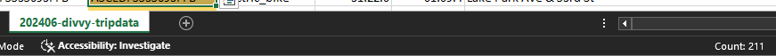

Excel_Count06_DuplicatedValues

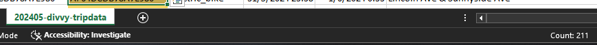

Excel_Count05_DuplicatedValues

We can even see the count that Excel makes down that the encountered values for each file counts 211. So, 211 x 2 (files) sums the total of 422, that is the number of duplicated values found before with R.

With this being found, now we will remove the duplicates; this means that 211 rows will be removed from the dataset.

To remove the duplicates we will use the “distinct” function referencing the *ride_id* field from the dataset.

```r
divvy_bikes_clean <- divvy_bikes %>%
  distinct(ride_id, .keep_all = TRUE)
glimpse(divvy_bikes_clean)
```

```
## Rows: 5,715,482
## Columns: 13
## $ ride_id            <chr> "903C30C2D810A53B", "F2FB18A98E110A2B", "D0DEC7C94E…
## $ rideable_type      <chr> "electric_bike", "electric_bike", "electric_bike", …
## $ started_at         <dttm> 2023-08-19 15:41:53, 2023-08-18 15:30:18, 2023-08-…
## $ ended_at           <dttm> 2023-08-19 15:53:36, 2023-08-18 15:45:25, 2023-08-…
## $ start_station_name <chr> "LaSalle St & Illinois St", "Clark St & Randolph St…
## $ start_station_id   <chr> "13430", "TA1305000030", "TA1305000030", "KA1504000…
## $ end_station_name   <chr> "Clark St & Elm St", NA, NA, NA, NA, NA, NA, NA, NA…
## $ end_station_id     <chr> "TA1307000039", NA, NA, NA, NA, NA, NA, NA, NA, NA,…
## $ start_lat          <dbl> 41.89072, 41.88451, 41.88498, 41.90310, 41.88555, 4…
## $ start_lng          <dbl> -87.63148, -87.63155, -87.63079, -87.63467, -87.632…
## $ end_lat            <dbl> 41.90297, 41.93000, 41.91000, 41.90000, 41.89000, 4…
## $ end_lng            <dbl> -87.63128, -87.64000, -87.63000, -87.62000, -87.680…
## $ member_casual      <chr> "member", "member", "member", "member", "member", "…
```

Now we can see that the 211 duplicated rows/values were removed.

The number of rows in total for the new cleaned dataset is 5715482.

*Note: 5715693 (Original dataset) - 211 (duplicated values) = 5715482 (Cleaned dataset)*

## Getting more info about the dataset

For calculating the ride length of each ride in the dataset, we will create a new column *ride_length* that will be the difference between *started_at* and *ended_at* in minutes

```r
divvy_bikes_processed <- divvy_bikes_clean %>%
  mutate(ride_length = round(difftime(ended_at, started_at, units = "mins"), digits = 2))
```

In addition, we will check if the values for the calculated column *ride_length* are correct by checking if there are negative values.

```r
negative_ride_length <- divvy_bikes_processed %>%
  filter(ride_length < 0)
negative_ride_length
```

```
## # A tibble: 404 × 14
##    ride_id          rideable_type started_at          ended_at
##    <chr>            <chr>         <dttm>              <dttm>
##  1 BEA2E3C59F6C9064 electric_bike 2023-08-16 14:42:56 2023-08-16 14:42:55
##  2 68203D8EB3D3F2AC electric_bike 2023-08-27 18:37:38 2023-08-27 18:37:35
##  3 62F4F440D6560E70 electric_bike 2023-08-21 15:34:39 2023-08-21 15:31:56
##  4 2BFB23CDC9A75AB0 electric_bike 2023-08-26 10:19:36 2023-08-26 10:16:52
##  5 8FD41344538C6DAD electric_bike 2023-08-04 21:28:08 2023-08-04 21:28:06
##  6 88C6795EB8654AF5 electric_bike 2023-08-19 03:01:47 2023-08-19 03:00:12
##  7 197D33FAF6396DDC electric_bike 2023-08-18 16:01:29 2023-08-18 16:01:28
##  8 7FC22D5B6730A327 electric_bike 2023-08-03 08:16:04 2023-08-03 08:13:34
##  9 82B071A054A869E0 electric_bike 2023-08-19 16:19:27 2023-08-19 16:19:25
## 10 41884873E3E524D3 electric_bike 2023-08-03 17:19:37 2023-08-03 17:19:14
## # ℹ 394 more rows
## # ℹ 10 more variables: start_station_name <chr>, start_station_id <chr>,
## #   end_station_name <chr>, end_station_id <chr>, start_lat <dbl>,
## #   start_lng <dbl>, end_lat <dbl>, end_lng <dbl>, member_casual <chr>,
## #   ride_length <drtn>
```

We can see that there are negative values in the *ride_length* column, what it means that some values from the *started_at* field were entered in the *ended_at* field and viceverse.

To correct this mistake in the dataset we will fix this values to change them to the correct column by using a condition statement or code to validate the values in the two columns.

```r
divvy_bikes_processed <- divvy_bikes_processed %>%
  mutate(new_started_at = ifelse(ride_length < 0, as_datetime(ended_at), as_datetime(started_at)),
         new_ended_at = ifelse(ride_length < 0, as_datetime(started_at), as_datetime(ended_at)),
         started_at = as_datetime(new_started_at), ended_at = as_datetime(new_ended_at)) %>%
  select(-new_started_at, -new_ended_at)
```

And now we will calculate the ride length once again with the corrected columns.

```r
divvy_bikes_processed <- divvy_bikes_processed %>%
  mutate(ride_length = round(difftime(ended_at, started_at, units = "mins"), digits = 2))
```

We will validate once again if the cleaned dataset still has negative values in the *ride_length* column.

```r
negative_ride_length <- divvy_bikes_processed %>%
  filter(ride_length < 0)
negative_ride_length
```

```
## # A tibble: 0 × 14
## # ℹ 14 variables: ride_id <chr>, rideable_type <chr>, started_at <dttm>,
## #   ended_at <dttm>, start_station_name <chr>, start_station_id <chr>,
## #   end_station_name <chr>, end_station_id <chr>, start_lat <dbl>,
## #   start_lng <dbl>, end_lat <dbl>, end_lng <dbl>, member_casual <chr>,
## #   ride_length <drtn>
```

There is not negative values anymore.

Also, we will create a new column *day_of_week* to calculate which day of the week is each ride starting

```r
divvy_bikes_processed <- divvy_bikes_processed %>%
  mutate(day_of_week = weekdays(as.Date(started_at)))
head(divvy_bikes_processed)
```

```
## # A tibble: 6 × 15
##   ride_id          rideable_type started_at          ended_at
##   <chr>            <chr>         <dttm>              <dttm>
## 1 903C30C2D810A53B electric_bike 2023-08-19 15:41:53 2023-08-19 15:53:36
## 2 F2FB18A98E110A2B electric_bike 2023-08-18 15:30:18 2023-08-18 15:45:25
## 3 D0DEC7C94E4663DA electric_bike 2023-08-30 16:15:08 2023-08-30 16:27:37
## 4 E0DDDC5F84747ED9 electric_bike 2023-08-30 16:24:07 2023-08-30 16:33:34
## 5 7797A4874BA260CA electric_bike 2023-08-22 15:59:44 2023-08-22 16:20:38
## 6 DF4DE734EBC4DF66 electric_bike 2023-08-24 12:27:24 2023-08-24 12:54:59
## # ℹ 11 more variables: start_station_name <chr>, start_station_id <chr>,
## #   end_station_name <chr>, end_station_id <chr>, start_lat <dbl>,
## #   start_lng <dbl>, end_lat <dbl>, end_lng <dbl>, member_casual <chr>,
## #   ride_length <drtn>, day_of_week <chr>
```

This way, we have obtained more information about the dataset

Now we can conclude that **the dataset is correct and clean**.

## Analyze the dataset and calculations

### Getting Calculations

#### Getting calculations per day of the week

To analyze the data we will get the mean, max and mode of the dataset grouping by the *member_casual* column to obtain more information about the ride length and day of the week for the two types of membership.

```r
calculations_member_casual <- divvy_bikes_processed %>%
  group_by(member_casual) %>%
  summarise(avg_ride_length = mean(ride_length), max_ride_length = max(ride_length), median(ride_length), min(ride_length), mode_day_of_week = Mode(day_of_week), num_of_rides = n_distinct(ride_id))
calculations_member_casual
```

```
## # A tibble: 2 × 7
##   member_casual avg_ride_length max_ride_length `median(ride_length)`
##   <chr>         <drtn>          <drtn>          <drtn>
## 1 casual        27.15739 mins   98489.07 mins   12.20 mins
## 2 member        13.00704 mins   16635.22 mins    8.73 mins
## # ℹ 3 more variables: `min(ride_length)` <drtn>, mode_day_of_week <chr>,
## #   num_of_rides <int>
```

In the result we can see the average of the ride length, max, min and median ride length, and most common day of the week for each member type.

Now we will calculate the average ride length and total number of rides grouping by type of member and day of the week

```r
pivot_table <- divvy_bikes_processed %>%
  group_by(member_casual, day_of_week) %>%
  summarise(avg_ride_length = mean(ride_length), num_of_rides = n_distinct(ride_id))
pivot_table
```

```
## # A tibble: 14 × 4
## # Groups:   member_casual [2]
##    member_casual day_of_week avg_ride_length num_of_rides
##    <chr>         <chr>       <drtn>                 <int>
##  1 casual        domingo     31.92722 mins         340723
##  2 casual        jueves      24.10050 mins         255637
##  3 casual        lunes       26.26931 mins         225902
##  4 casual        martes      23.44512 mins         234820
##  5 casual        miércoles   23.44535 mins         266150
##  6 casual        sábado      30.36386 mins         415227
##  7 casual        viernes     26.77450 mins         299983
##  8 member        domingo     14.51341 mins         408653
##  9 member        jueves      12.46100 mins         576543
## 10 member        lunes       12.37517 mins         503914
## 11 member        martes      12.48452 mins         583225
## 12 member        miércoles   12.73482 mins         616036
## 13 member        sábado      14.32431 mins         471116
## 14 member        viernes     12.75488 mins         517553
```

Also, we can visualize each day of the week for each type of member that had the most number of rides

```r
max_num_of_rides <- pivot_table %>%
  group_by(member_casual) %>%
  slice_max(num_of_rides)
max_num_of_rides
```

```
## # A tibble: 2 × 4
## # Groups:   member_casual [2]
##   member_casual day_of_week avg_ride_length num_of_rides
##   <chr>         <chr>       <drtn>                 <int>
## 1 casual        sábado      30.36386 mins         415227
## 2 member        miércoles   12.73482 mins         616036
```

The day with most rides for the casual riders is Saturday with 415227 rides.

The day with most rides for the member riders is Wednesday with 616036 rides.

And we can see the percentage of rides that were taken for each day of the week

```r
daily_rides_percentage <- divvy_bikes_processed %>%
  group_by(day_of_week) %>%
  summarise(num_of_rides = n_distinct(ride_id)) %>%
  mutate(percentage =  (num_of_rides / sum(num_of_rides)) * 100)
daily_rides_percentage
```

```
## # A tibble: 7 × 3
##   day_of_week num_of_rides percentage
##   <chr>              <int>      <dbl>
## 1 domingo           749376       13.1
## 2 jueves            832180       14.6
## 3 lunes             729816       12.8
## 4 martes            818045       14.3
## 5 miércoles         882186       15.4
## 6 sábado            886343       15.5
## 7 viernes           817536       14.3
```

We can see that Saturday is the day of the week that has the higher percentage or most rides during the year. Because of that we will analyze what is the behaviour of each type of members on that day (Saturday):

```r
saturday_rides <- pivot_table %>%
  filter(day_of_week == "sábado") %>%
  group_by(member_casual, day_of_week) %>%
  summarise(num_of_rides = sum(num_of_rides))
saturday_rides <- mutate(saturday_rides, percentage = (num_of_rides / sum(saturday_rides$num_of_rides)) * 100)
saturday_rides
```

```
## # A tibble: 2 × 4
## # Groups:   member_casual [2]
##   member_casual day_of_week num_of_rides percentage
##   <chr>         <chr>              <int>      <dbl>
## 1 casual        sábado            415227       46.8
## 2 member        sábado            471116       53.2
```

The member riders represent 53.2% of the rides that are taken in the busiest day of the week (Saturday), while casual members represent the 46.8% of the rides.

#### Getting calculations per season

We will first create a new column to identify the season of the time of the year that the ride is being taken.

```r
divvy_bikes_processed <- divvy_bikes_processed %>%
  mutate(season_of_year = ifelse(month(started_at) == 12 | month(started_at) == 1 | month(started_at) == 2, "Winter",
                                 ifelse(month(started_at) == 3 | month(started_at) == 4 | month(started_at) == 5, "Spring",
                                 ifelse(month(started_at) == 6 | month(started_at) == 7 | month(started_at) == 8, "Summer",
                                        "Autumn"))))

head(divvy_bikes_processed)
```

```
## # A tibble: 6 × 16
##   ride_id          rideable_type started_at          ended_at
##   <chr>            <chr>         <dttm>              <dttm>
## 1 903C30C2D810A53B electric_bike 2023-08-19 15:41:53 2023-08-19 15:53:36
## 2 F2FB18A98E110A2B electric_bike 2023-08-18 15:30:18 2023-08-18 15:45:25
## 3 D0DEC7C94E4663DA electric_bike 2023-08-30 16:15:08 2023-08-30 16:27:37
## 4 E0DDDC5F84747ED9 electric_bike 2023-08-30 16:24:07 2023-08-30 16:33:34
## 5 7797A4874BA260CA electric_bike 2023-08-22 15:59:44 2023-08-22 16:20:38
## 6 DF4DE734EBC4DF66 electric_bike 2023-08-24 12:27:24 2023-08-24 12:54:59
## # ℹ 12 more variables: start_station_name <chr>, start_station_id <chr>,
## #   end_station_name <chr>, end_station_id <chr>, start_lat <dbl>,
## #   start_lng <dbl>, end_lat <dbl>, end_lng <dbl>, member_casual <chr>,
## #   ride_length <drtn>, day_of_week <chr>, season_of_year <chr>
```

Now, we will calculate the average ride length and total number of rides grouping by type of member and season of the year.

```r
pivot_table_season <- divvy_bikes_processed %>%
  group_by(member_casual, season_of_year) %>%
  summarise(avg_ride_length = mean(ride_length), num_of_rides = n_distinct(ride_id)) %>%
  mutate(percentage = num_of_rides / sum(num_of_rides) * 100)
pivot_table_season
```

```
## # A tibble: 8 × 5
## # Groups:   member_casual [2]
##   member_casual season_of_year avg_ride_length num_of_rides percentage
##   <chr>         <chr>          <drtn>                 <int>      <dbl>
## 1 casual        Autumn         23.53489 mins         537098      26.3
## 2 casual        Spring         26.71057 mins         445378      21.8
## 3 casual        Summer         30.10985 mins         932671      45.8
## 4 casual        Winter         22.21774 mins         123295       6.05
## 5 member        Autumn         12.43640 mins        1028904      28.0
## 6 member        Spring         12.75438 mins         880827      24.0
## 7 member        Summer         13.77731 mins        1298494      35.3
## 8 member        Winter         12.60064 mins         468815      12.7
```

Also, we can visualize each season for each type of member that had the most number of rides

```r
max_num_of_rides_season <- pivot_table_season %>%
  group_by(member_casual) %>%
  slice_max(num_of_rides)
max_num_of_rides_season
```

```
## # A tibble: 2 × 5
## # Groups:   member_casual [2]
##   member_casual season_of_year avg_ride_length num_of_rides percentage
##   <chr>         <chr>          <drtn>                 <int>      <dbl>
## 1 casual        Summer         30.10985 mins         932671       45.8
## 2 member        Summer         13.77731 mins        1298494       35.3
```

The season with most rides for the casual riders is Summer with 932671 rides.

The season with most rides for the member riders is Summer with 1298494 rides.

And we can see the percentage of rides that were taken for each season

```r
season_rides_percentage <- divvy_bikes_processed %>%
  group_by(season_of_year) %>%
  summarise(num_of_rides = n_distinct(ride_id)) %>%
  mutate(percentage =  (num_of_rides / sum(num_of_rides)) * 100)
season_rides_percentage
```

```
## # A tibble: 4 × 3
##   season_of_year num_of_rides percentage
##   <chr>                 <int>      <dbl>
## 1 Autumn              1566002       27.4
## 2 Spring              1326205       23.2
## 3 Summer              2231165       39.0
## 4 Winter               592110       10.4
```

We can see that Summer is the season that has the higher percentage or most rides during the year. Because of that we will analyze what is the behaviour of each type of members on that season (Summer):

```r
summer_rides <- pivot_table_season %>%
  filter(season_of_year == "Summer") %>%
  group_by(member_casual, season_of_year) %>%
  summarise(num_of_rides = sum(num_of_rides))
summer_rides <- mutate(summer_rides, percentage = (num_of_rides / sum(summer_rides$num_of_rides)) * 100)
summer_rides
```

```
## # A tibble: 2 × 4
## # Groups:   member_casual [2]
##   member_casual season_of_year num_of_rides percentage
##   <chr>         <chr>                 <int>      <dbl>
## 1 casual        Summer               932671       41.8
## 2 member        Summer              1298494       58.2
```

The member riders represent 58.2% of the rides that are taken in the busiest season (Summer), while casual members represent the 41.8% of the rides.

#### Getting calculations per month

We will first create a new column to identify the month of the year that the ride is being taken.

```r
divvy_bikes_processed <- divvy_bikes_processed %>%
  mutate(month_of_year = month(started_at))
head(divvy_bikes_processed)
```

```
## # A tibble: 6 × 17
##   ride_id          rideable_type started_at          ended_at
##   <chr>            <chr>         <dttm>              <dttm>
## 1 903C30C2D810A53B electric_bike 2023-08-19 15:41:53 2023-08-19 15:53:36
## 2 F2FB18A98E110A2B electric_bike 2023-08-18 15:30:18 2023-08-18 15:45:25
## 3 D0DEC7C94E4663DA electric_bike 2023-08-30 16:15:08 2023-08-30 16:27:37
## 4 E0DDDC5F84747ED9 electric_bike 2023-08-30 16:24:07 2023-08-30 16:33:34
## 5 7797A4874BA260CA electric_bike 2023-08-22 15:59:44 2023-08-22 16:20:38
## 6 DF4DE734EBC4DF66 electric_bike 2023-08-24 12:27:24 2023-08-24 12:54:59
## # ℹ 13 more variables: start_station_name <chr>, start_station_id <chr>,
## #   end_station_name <chr>, end_station_id <chr>, start_lat <dbl>,
## #   start_lng <dbl>, end_lat <dbl>, end_lng <dbl>, member_casual <chr>,
## #   ride_length <drtn>, day_of_week <chr>, season_of_year <chr>,
## #   month_of_year <dbl>
```

Now, we will calculate the average ride length and total number of rides grouping by type of member and month of the year.

```r
pivot_table_month <- divvy_bikes_processed %>%
  group_by(member_casual, month_of_year) %>%
  summarise(avg_ride_length = mean(ride_length), num_of_rides = n_distinct(ride_id)) %>%
  mutate(percentage = (num_of_rides / sum(num_of_rides)) * 100)
pivot_table_month
```

```
## # A tibble: 24 × 5
## # Groups:   member_casual [2]
##    member_casual month_of_year avg_ride_length num_of_rides percentage
##    <chr>                 <dbl> <drtn>                 <int>      <dbl>
##  1 casual                    1 21.30664 mins          24460       1.20
##  2 casual                    2 25.18987 mins          47163       2.31
##  3 casual                    3 24.95505 mins          82550       4.05
##  4 casual                    4 26.01160 mins         131810       6.47
##  5 casual                    5 27.73667 mins         231018      11.3
##  6 casual                    6 27.70557 mins         301169      14.8
##  7 casual                    7 27.38433 mins         320372      15.7
##  8 casual                    8 35.24365 mins         311130      15.3
##  9 casual                    9 25.18416 mins         261635      12.8
## 10 casual                   10 23.11470 mins         177074       8.69
## # ℹ 14 more rows
```

Also, we can visualize each month for each type of member that had the most number of rides

```r
max_num_of_rides_month <- pivot_table_month %>%
  group_by(member_casual) %>%
  slice_max(num_of_rides)
max_num_of_rides_month
```

```
## # A tibble: 2 × 5
## # Groups:   member_casual [2]
##   member_casual month_of_year avg_ride_length num_of_rides percentage
##   <chr>                 <dbl> <drtn>                 <int>      <dbl>
## 1 casual                    7 27.38433 mins         320372       15.7
## 2 member                    8 13.77204 mins         460563       12.5
```

The month with most rides for the casual riders is July with 320372 rides.

The month with most rides for the member riders is August with 460563 rides.

And we can see the percentage of rides that were taken for each month

```r
monthly_rides_percentage <- divvy_bikes_processed %>%
  group_by(month_of_year) %>%
  summarise(num_of_rides = n_distinct(ride_id)) %>%
  mutate(percentage =  (num_of_rides / sum(num_of_rides)) * 100)
monthly_rides_percentage
```

```
## # A tibble: 12 × 3
##    month_of_year num_of_rides percentage
##            <dbl>        <int>      <dbl>
##  1             1       144873       2.53
##  2             2       223164       3.90
##  3             3       301687       5.28
##  4             4       415025       7.26
##  5             5       609493      10.7
##  6             6       710747      12.4
##  7             7       748725      13.1
##  8             8       771693      13.5
##  9             9       666371      11.7
## 10            10       537119       9.40
## 11            11       362512       6.34
## 12            12       224073       3.92
```

We can see that August is the month that has the higher percentage or most rides during the year. Because of that we will analyze what is the behaviour of each type of member on that month (August):

```r
august_rides <- pivot_table_month %>%
  filter(month_of_year == 8) %>%
  group_by(member_casual, month_of_year) %>%
  summarise(num_of_rides = sum(num_of_rides))
august_rides <- mutate(august_rides, percentage = (num_of_rides / sum(august_rides$num_of_rides)) * 100)
august_rides
```

```
## # A tibble: 2 × 4
## # Groups:   member_casual [2]
##   member_casual month_of_year num_of_rides percentage
##   <chr>                 <dbl>        <int>      <dbl>
## 1 casual                    8       311130       40.3
## 2 member                    8       460563       59.7
```

The member riders represent 59.7% of the rides that are taken in the busiest month (August), while casual members represent the 40.3% of the rides.

#### Additional pivot table - consolidated

In addition, we will create a consolidated pivot table that can be used for making interactive visualizations if it is needed.

```r
pivot_table_consolidated <- divvy_bikes_processed %>%
  group_by(member_casual, season_of_year, month_of_year, day_of_week) %>%
  summarise(avg_ride_length = mean(ride_length), num_of_rides = n_distinct(ride_id))
```

[output not shown]

```r
pivot_table_consolidated
```

```
## # A tibble: 168 × 6
## # Groups:   member_casual, season_of_year, month_of_year [24]
##    member_casual season_of_year month_of_year day_of_week avg_ride_length
##    <chr>         <chr>                  <dbl> <chr>       <drtn>
##  1 casual        Autumn                     9 domingo     30.29425 mins
##  2 casual        Autumn                     9 jueves      20.69135 mins
##  3 casual        Autumn                     9 lunes       25.99171 mins
##  4 casual        Autumn                     9 martes      19.61251 mins
##  5 casual        Autumn                     9 miércoles   19.48175 mins
##  6 casual        Autumn                     9 sábado      28.16613 mins
##  7 casual        Autumn                     9 viernes     24.11483 mins
##  8 casual        Autumn                    10 domingo     28.94837 mins
##  9 casual        Autumn                    10 jueves      18.13112 mins
## 10 casual        Autumn                    10 lunes       21.92690 mins
## # ℹ 158 more rows
## # ℹ 1 more variable: num_of_rides <int>
```

Also, we can visualize each type of member that had the most number of rides according to the day, month and season

```r
max_num_of_rides_consolidated <- pivot_table_consolidated %>%
  group_by(member_casual) %>%
  slice_max(num_of_rides)
max_num_of_rides_consolidated
```

```
## # A tibble: 2 × 6
## # Groups:   member_casual [2]
##   member_casual season_of_year month_of_year day_of_week avg_ride_length
##   <chr>         <chr>                  <dbl> <chr>       <drtn>
## 1 casual        Autumn                     9 sábado      28.16613 mins
## 2 member        Summer                     8 martes      13.15050 mins
## # ℹ 1 more variable: num_of_rides <int>
```

The most rides for the casual riders occur in Autumn, on September, on a Saturday with 68408 rides.

The most rides for the member riders occur in Summer, on August, on a Tuesday with 82787 rides.

## Visualizations

Now we will display some visualizations about the analysis that we made before

#### Per day of the week

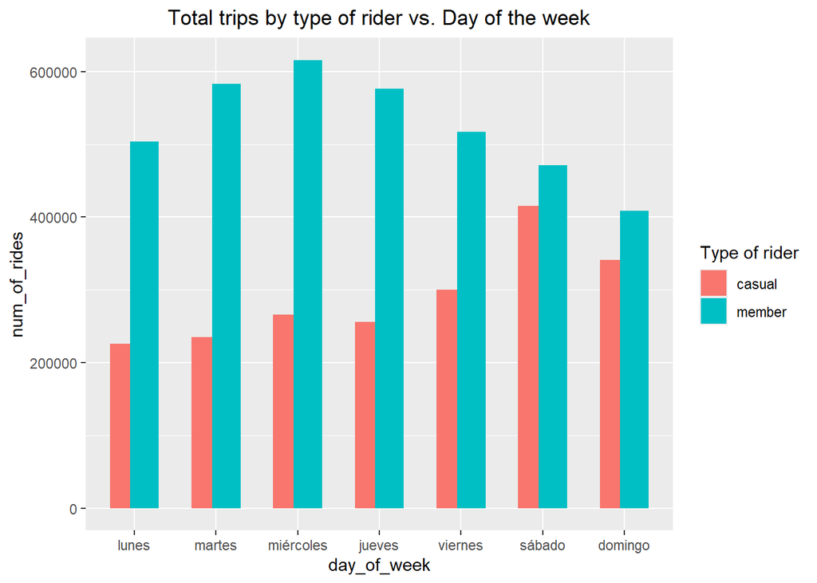

```r
pivot_table %>%
  mutate(day_of_week = factor(day_of_week, levels = c('lunes', 'martes', 'miércoles', 'jueves', 'viernes', 'sábado', 'domingo'))) %>%
  ggplot(aes(x = day_of_week, y = num_of_rides, fill = member_casual)) +
  geom_col(width = 0.7, position = position_dodge(width=0.5)) +
  ggtitle("Total trips by type of rider vs. Day of the week") +
  theme(plot.title = element_text(hjust=0.5)) +
  scale_y_continuous(labels = function(x) format(x, scientific = FALSE)) +
  labs(fill = "Type of rider")
```

From the visualization above, here we can determine what we talked before but in a more visual way.

We determine that **Wednesday is the day of the week with more member riders** followed by Tuesday.

On the other hand, **Saturday is the day with more casual riders** followed by Sunday.

This means that the casual drivers make the use of bikes more often during the weekends, while member riders are more busy during the week.

The busiest day of the week among all type of riders is Saturday and we can see it in the next visualization:

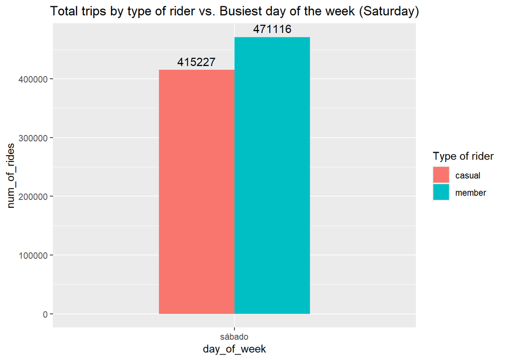

```r
saturday_rides %>%
  ggplot(aes(x = day_of_week, y = num_of_rides, fill = member_casual)) +
  geom_col(position = "dodge", width = 0.5, stat='identity') +
  ggtitle("Total trips by type of rider vs. Busiest day of the week (Saturday)") +
  theme(plot.title = element_text(hjust=0.5)) +
  scale_y_continuous(labels = function(x) format(x, scientific = FALSE)) +
  labs(fill = "Type of rider") +
  geom_text(aes(label = num_of_rides),
            position=position_dodge(width=0.5), size = 4,vjust=-0.5)
```

#### Per month and season

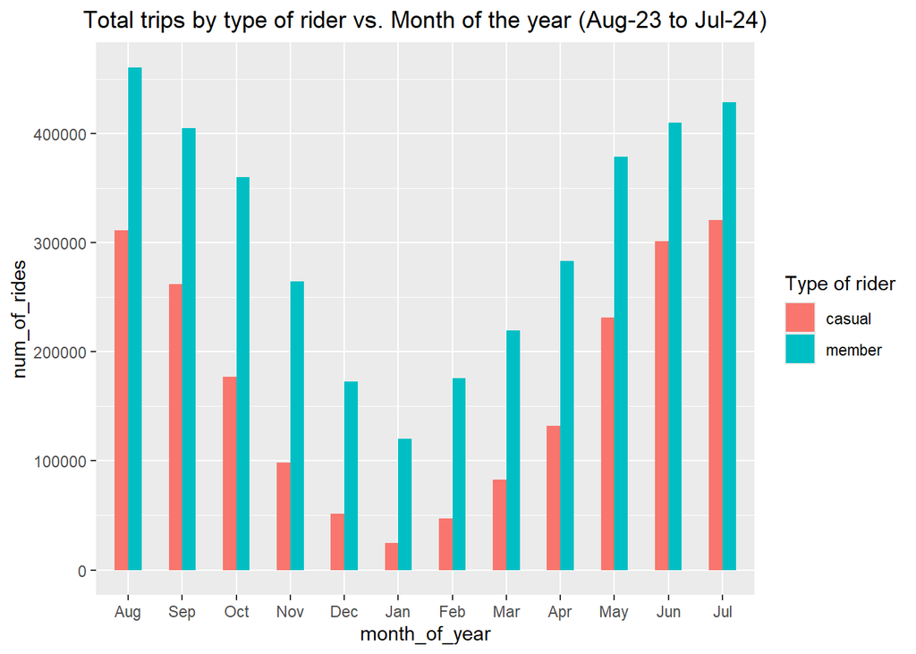

```r
pivot_table_month %>%
  mutate(month_of_year = month.abb[month_of_year]) %>%
  mutate(month_of_year = factor(month_of_year, levels = c('Aug', 'Sep', 'Oct', 'Nov', 'Dec', 'Jan', 'Feb', 'Mar', 'Apr', 'May', 'Jun', 'Jul'))) %>%
  ggplot(aes(x = month_of_year, y = num_of_rides, fill = member_casual)) +
  geom_col(width = 0.5, position = position_dodge(width=0.5)) +
  ggtitle("Total trips by type of rider vs. Month of the year (Aug-23 to Jul-24)") +
  theme(plot.title = element_text(hjust=0.5)) +
  scale_y_continuous(labels = function(x) format(x, scientific = FALSE)) +
  labs(fill = "Type of rider")
```

We determine that **August (2023) is the month with the most member riders** followed by July (2024)

On the other hand, **July (2024) is the month with the most casual riders** followed by August (2023)

Also we can visualize this in two different visualizations for each one to see it much better:

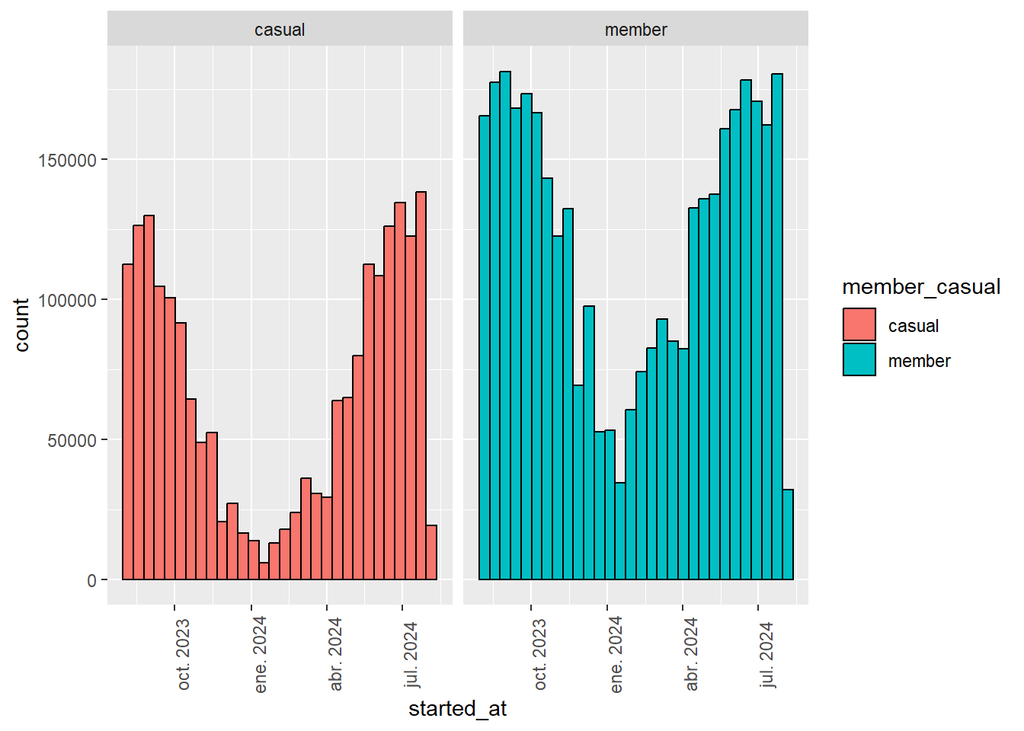

```r
divvy_bikes_processed %>%
  ggplot(aes(started_at)) +
  geom_histogram(color = "#000000", aes(fill = member_casual)) +
  theme(axis.text.x = element_text(angle = 90)) +
  facet_wrap(~member_casual)
```

With the last visualization we can divide this into seasons to understand which season is the busiest one for each type of rider:

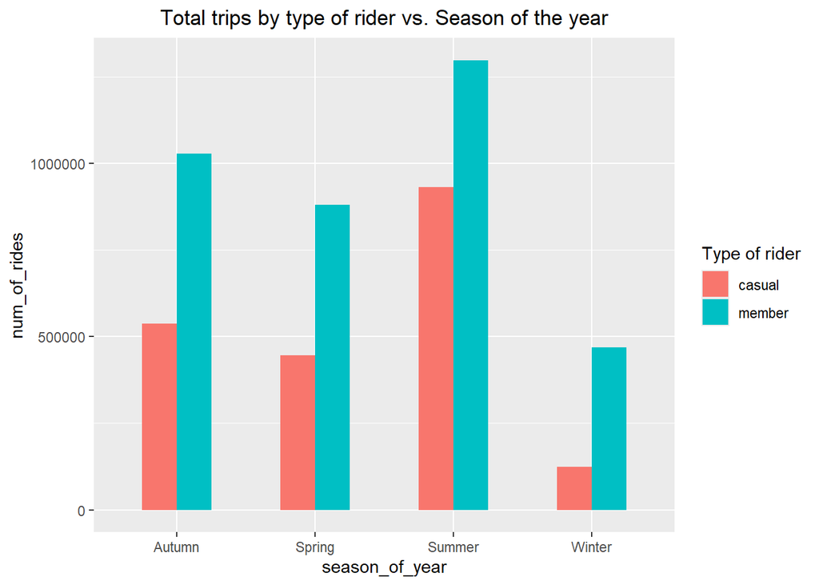

```r
pivot_table_season %>%
  ggplot(aes(x = season_of_year, y = num_of_rides, fill = member_casual)) +
  geom_col(width = 0.5, position = position_dodge(width=0.5)) +
  ggtitle("Total trips by type of rider vs. Season of the year") +
  theme(plot.title = element_text(hjust=0.5)) +
  scale_y_continuous(labels = function(x) format(x, scientific = FALSE)) +
  labs(fill = "Type of rider")
```

We can see that Summer is the busiest season for both types of rider: casual and member, followed by Autumn. And the lowest season is Winter.

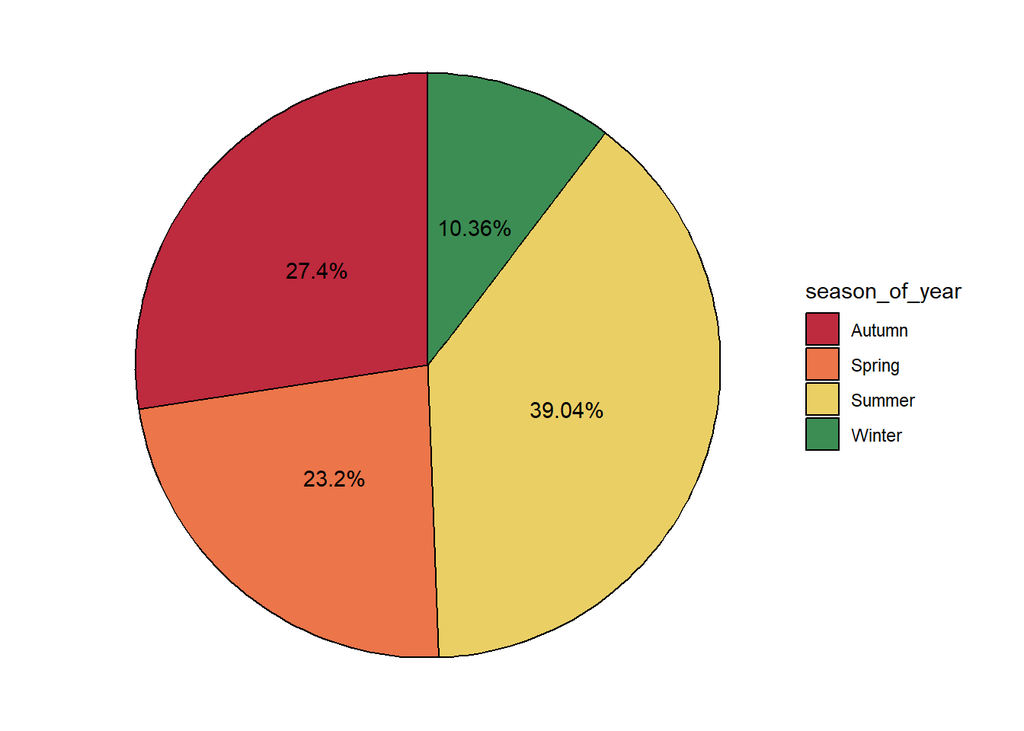

```r
season_rides_percentage %>%
  ggplot(aes(x="", y=percentage, fill=season_of_year)) +
  geom_col(color = "black") +
  geom_text(aes(label = str_c(round(percentage, digits = 2), "%", sep = "")),
            position = position_stack(vjust = 0.5)) +
  coord_polar("y", start=0) +
  scale_fill_manual(values = c("#BE2A3E", "#EC754A",
                               "#EACF65", "#3C8D53")) +
  theme_void()
```

Checking more in detail the Summer season:

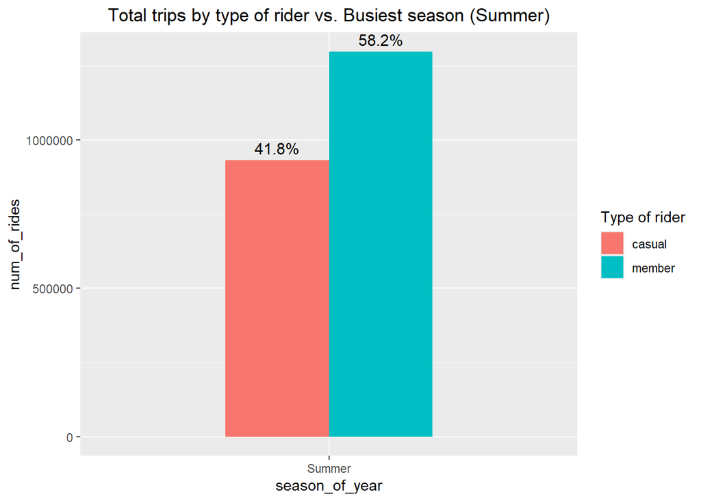

```r
summer_rides %>%
  ggplot(aes(x = season_of_year, y = num_of_rides, fill = member_casual)) +
  geom_col(position = "dodge", width = 0.5, stat='identity') +
  ggtitle("Total trips by type of rider vs. Busiest season (Summer)") +
  theme(plot.title = element_text(hjust=0.5)) +
  scale_y_continuous(labels = function(x) format(x, scientific = FALSE)) +
  labs(fill = "Type of rider") +
  geom_text(aes(label = str_c(round(percentage, digits = 2), "%", sep = "")  ),
            position=position_dodge(width=0.5), size = 4,vjust=-0.5)
```

As we said before: The member riders represent 58.2% of the rides that are taken in the busiest season (Summer), while casual members represent the 41.8% of the rides.

### Average trip duration

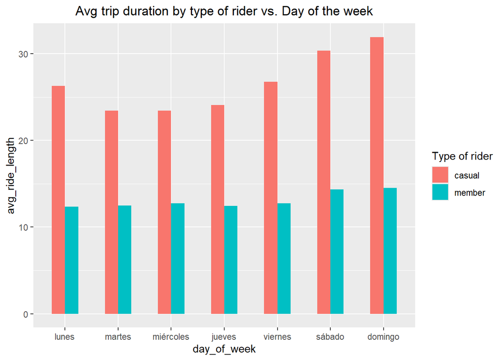

```r
pivot_table %>%
  mutate(day_of_week = factor(day_of_week, levels = c('lunes', 'martes', 'miércoles', 'jueves', 'viernes', 'sábado', 'domingo'))) %>%
  ggplot(aes(x = day_of_week, y = avg_ride_length, fill = member_casual)) +
  geom_col(width = 0.5, position = position_dodge(width=0.5)) +
  ggtitle("Avg trip duration by type of rider vs. Day of the week") +
  theme(plot.title = element_text(hjust=0.5)) +
  scale_y_continuous(labels = function(x) format(x, scientific = FALSE)) +
  labs(fill = "Type of rider")
```

We can see in this visualization that the highest average for trip duration for casual and member riders is on Sunday, followed by Saturday.

This means that the longest rides are happening on the weekends.

We can also see that the casual riders prefer longer trips than the member riders. But the member riders have more amount of rides than the casual riders, as we analyzed in the section **“Getting calculations per day of the week”**.

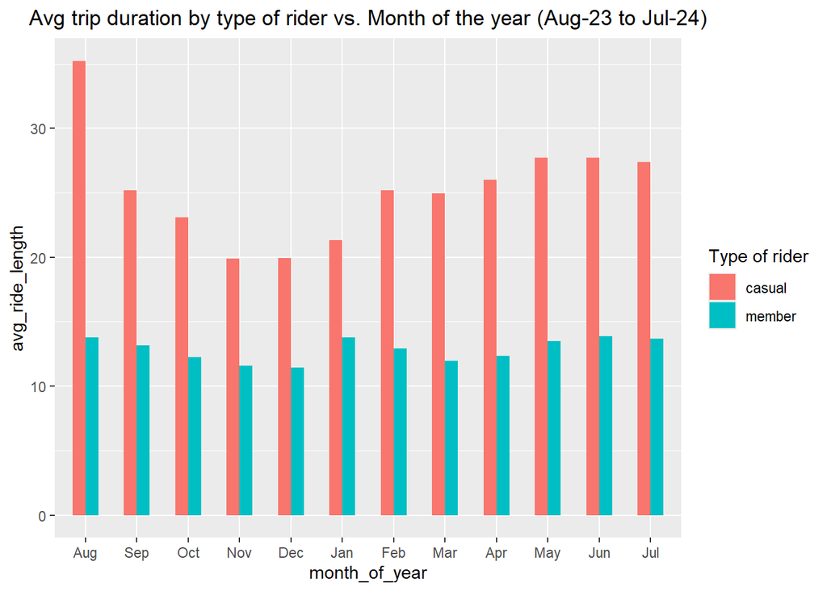

```r
pivot_table_month %>%
  mutate(month_of_year = month.abb[month_of_year]) %>%
  mutate(month_of_year = factor(month_of_year, levels = c('Aug', 'Sep', 'Oct', 'Nov', 'Dec', 'Jan', 'Feb', 'Mar', 'Apr', 'May', 'Jun', 'Jul'))) %>%
  ggplot(aes(x = month_of_year, y = avg_ride_length, fill = member_casual)) +
  geom_col(width = 0.5, position = position_dodge(width=0.5)) +
  ggtitle("Avg trip duration by type of rider vs. Month of the year (Aug-23 to Jul-24)") +
  theme(plot.title = element_text(hjust=0.5)) +
  scale_y_continuous(labels = function(x) format(x, scientific = FALSE)) +
  labs(fill = "Type of rider")
```

```r
max_avg_rides_month <- pivot_table_month %>%
  group_by(member_casual) %>%
  slice_max(avg_ride_length) %>%
  select(-percentage)
max_avg_rides_month
```

```
## # A tibble: 2 × 4
## # Groups:   member_casual [2]
##   member_casual month_of_year avg_ride_length num_of_rides
##   <chr>                 <dbl> <drtn>                 <int>
## 1 casual                    8 35.24365 mins         311130
## 2 member                    6 13.88715 mins         409578
```

The visualization above determine that the month of August is the one with the highest average of trip duration for the casual riders followed by May.On the other hand th emonth of June is the highest average of trip duration for member riders, followed by August.

This visualization really shows that the casual riders prefer longer trips than the member riders. But the members riders have more rides than the casual riders that we analyzed in the section **“Getting calculations per month”**.

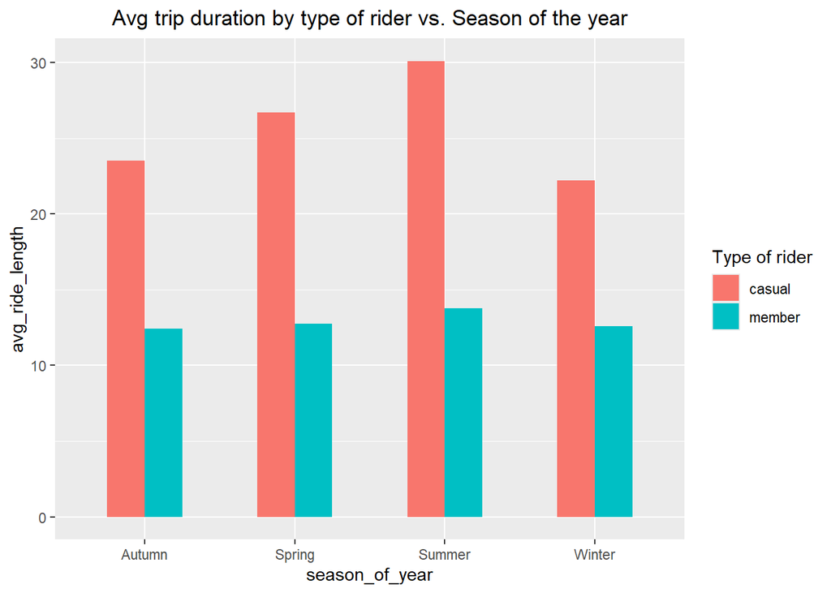

```r
pivot_table_season %>%
  ggplot(aes(x = season_of_year, y = avg_ride_length, fill = member_casual)) +
  geom_col(width = 0.5, position = position_dodge(width=0.5)) +
  ggtitle("Avg trip duration by type of rider vs. Season of the year") +
  theme(plot.title = element_text(hjust=0.5)) +
  scale_y_continuous(labels = function(x) format(x, scientific = FALSE)) +
  labs(fill = "Type of rider")
```

```r
max_avg_rides_season <- pivot_table_season %>%
  group_by(member_casual) %>%
  slice_max(avg_ride_length) %>%
  select(-percentage)
max_avg_rides_season
```

```
## # A tibble: 2 × 4
## # Groups:   member_casual [2]
##   member_casual season_of_year avg_ride_length num_of_rides
##   <chr>         <chr>          <drtn>                 <int>
## 1 casual        Summer         30.10985 mins         932671
## 2 member        Summer         13.77731 mins        1298494
```

The visualization above determine that the Summer season is the one who has the highest average of trip duration for both casual and member riders.

Here, we can also see that the casual riders prefer longer trips than the member riders. But the member riders have more amount of rides than the casual riders, as we analyzed in the section **“Getting calculations per season”**.